# Practical Machine Learning - Prediction Assignment Writeup

## Background

Using devices such as Jawbone Up, Nike FuelBand, and Fitbit it is now possible to collect a large amount of data about personal activity relatively inexpensively. These type of devices are part of the quantified self movement – a group of enthusiasts who take measurements about themselves regularly to improve their health, to find patterns in their behavior, or because they are tech geeks. One thing that people regularly do is quantify how much of a particular activity they do, but they rarely quantify how well they do it.

The goal of this project is to predict the manner in which the participants did the exercise. This is the ‘classe’ variable of the training set, which classifies the correct and incorrect outcomes into A, B, C, D, and E categories.

More information is available from the website http://groupware.les.inf.puc-rio.br/har

### Data Loading and Cleaning

The training data for this project are available here: https://d396qusza40orc.cloudfront.net/predmachlearn/pml-training.csv

The test data are available here: https://d396qusza40orc.cloudfront.net/predmachlearn/pml-testing.csv

We will first download the data from the URLs above, and do some initial clean-up

```r
# set the working directory
#setwd("./Documents/projects/data-science/practical_machine_learning/")
# download the data from the given URLs
if (!file.exists("./pml-training.csv"))
        download.file("https://d396qusza40orc.cloudfront.net/predmachlearn/pml-training.csv", destfile = "./pml-training.csv")
if (!file.exists("./pml-testing.csv"))
        download.file("http://d396qusza40orc.cloudfront.net/predmachlearn/pml-testing.csv", destfile = "./pml-testing.csv")
#load the csv files
training_data = read.csv("pml-training.csv", na.strings=c("", "NA", "NULL"))
testing_data = read.csv("pml-testing.csv", na.strings=c("", "NA", "NULL"))
dim(training_data)
```

```
## [1] 19622   160
```

```r
dim(testing_data)
```

```
## [1]  20 160
```

Always a good idea to take a quick look at the data, particularly “classe” variable which we are trying to predict

```r
str(training_data, list.len=15)
```

```
## 'data.frame':    19622 obs. of  160 variables:
##  $ X                       : int  1 2 3 4 5 6 7 8 9 10 ...
##  $ user_name               : Factor w/ 6 levels "adelmo","carlitos",..: 2 2 2 2 2 2 2 2 2 2 ...
##  $ raw_timestamp_part_1    : int  1323084231 1323084231 1323084231 1323084232 1323084232 1323084232 1323084232 1323084232 1323084232 1323084232 ...
##  $ raw_timestamp_part_2    : int  788290 808298 820366 120339 196328 304277 368296 440390 484323 484434 ...
##  $ cvtd_timestamp          : Factor w/ 20 levels "02/12/2011 13:32",..: 9 9 9 9 9 9 9 9 9 9 ...
##  $ new_window              : Factor w/ 2 levels "no","yes": 1 1 1 1 1 1 1 1 1 1 ...
##  $ num_window              : int  11 11 11 12 12 12 12 12 12 12 ...
##  $ roll_belt               : num  1.41 1.41 1.42 1.48 1.48 1.45 1.42 1.42 1.43 1.45 ...
##  $ pitch_belt              : num  8.07 8.07 8.07 8.05 8.07 8.06 8.09 8.13 8.16 8.17 ...
##  $ yaw_belt                : num  -94.4 -94.4 -94.4 -94.4 -94.4 -94.4 -94.4 -94.4 -94.4 -94.4 ...
##  $ total_accel_belt        : int  3 3 3 3 3 3 3 3 3 3 ...
##  $ kurtosis_roll_belt      : Factor w/ 396 levels "-0.016850","-0.021024",..: NA NA NA NA NA NA NA NA NA NA ...
##  $ kurtosis_picth_belt     : Factor w/ 316 levels "-0.021887","-0.060755",..: NA NA NA NA NA NA NA NA NA NA ...
##  $ kurtosis_yaw_belt       : Factor w/ 1 level "#DIV/0!": NA NA NA NA NA NA NA NA NA NA ...
##  $ skewness_roll_belt      : Factor w/ 394 levels "-0.003095","-0.010002",..: NA NA NA NA NA NA NA NA NA NA ...
##   [list output truncated]
```

```r
table(training_data$classe)
```

```
##
##    A    B    C    D    E
## 5580 3797 3422 3216 3607
```

```r
training_data <- training_data[, 7:160]
testing_data  <- testing_data[, 7:160]
dim(training_data)
```

```
## [1] 19622   154
```

```r
dim(testing_data)
```

```
## [1]  20 154
```

Also, we will get rid of the columns that are mostly NA

```r
training_data <- training_data[ , colSums(is.na(training_data)) == 0]
testing_data <- testing_data[ , colSums(is.na(testing_data)) == 0]
dim(training_data)
```

```
## [1] 19622    54
```

```r
dim(testing_data)
```

```
## [1] 20 54
```

### Data Partitioning and Prediction Modeling

We split the training set into two for cross validation purposes. We randomly subsample 60% of the set for training purposes, and the remaining 40% will be used for testing, evaluation and accuracy measurement. We will never use testing sample for training / modelling.

```r
library(caret)
set.seed(3141592)
training_set <- createDataPartition(y=training_data$classe, p=0.60, list=FALSE)
train1  <- training_data[training_set,]
train2  <- training_data[-training_set,]
dim(train1)
```

```
## [1] 11776    54
```

```r
dim(train2)
```

```
## [1] 7846   54
```

Before we do any modelling, we have to make sure that the variables do not have have extremely low variance and also check for highly correlated variables.

```r
# check the variables that has extemely low variance
zeroVar= nearZeroVar(train1[sapply(train1, is.numeric)], saveMetrics = TRUE)
train1 = train1[,zeroVar[, 'nzv']==0]
dim(train1)
```

```
## [1] 11776    54
```

Now, let’s take a look how highly variables are correlated. 53 covariates is a lot of variables and is always a good idea to check for the relative importance of these variables. We will be using randomForest to quickly review the relative importance of these covariates.

```r
library(randomForest)
```

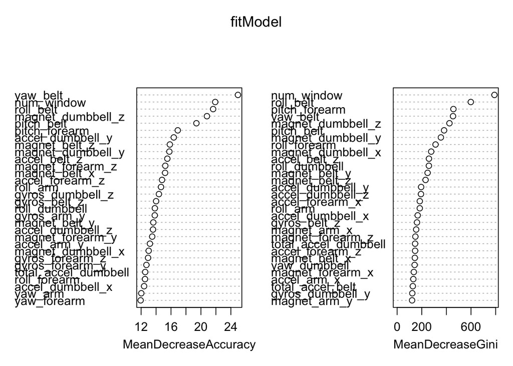

```r
set.seed(3141592)
fitModel <- randomForest(classe~., data=train1, importance=TRUE, ntree=100)
varImpPlot(fitModel)
```

Let’s analyze the correlations between these 10 variables. The following code calculates the correlation matrix, replaces the 1s in the diagonal with 0s, and outputs which variables have an absolute value correlation above 75%:

```r
correl = cor(train1[,c("yaw_belt","roll_belt","num_window","pitch_belt","magnet_dumbbell_z","magnet_dumbbell_y","pitch_forearm","accel_dumbbell_y","roll_arm","roll_forearm")])
diag(correl) <- 0
which(abs(correl)>0.75, arr.ind=TRUE)
```

```
##           row col
## roll_belt   2   1
## yaw_belt    1   2
```

roll_belt and yaw_belt have a high correlation and it may be a bit risky to remove them both. We will remove just one (yaw_belt) from the list of 10 variables.

#### Modeling

```r
library(caret)
set.seed(3141592)
fitControl2<-trainControl(method="cv", number=5, allowParallel=T, verbose=T)
fitModel<-train(classe~ roll_belt+num_window+pitch_belt+magnet_dumbbell_y+magnet_dumbbell_z+pitch_forearm+accel_dumbbell_y+roll_arm+roll_forearm,data=train1, method="rf", trControl=fitControl2, verbose=F)
#fitModel <- train(classe~roll_belt+num_window+pitch_belt+magnet_dumbbell_y+magnet_dumbbell_z+pit#ch_forearm+accel_dumbbell_y+roll_arm+roll_forearm,
#                  data=train1,
#                  method="rf",
#                  trControl=trainControl(method="cv",number=2),
#                  prox=TRUE,
#                  verbose=TRUE,
#                  allowParallel=TRUE)
```

### Accuracy

We will use caret’s confusionMatrix() function applied on train2 (the test set) to get an idea of the accuracy:

```r
predictions <- predict(fitModel, newdata=train2)
confusionMat <- confusionMatrix(predictions, train2$classe)
confusionMat
```

```
## Confusion Matrix and Statistics
##
##           Reference
## Prediction    A    B    C    D    E
##          A 2231    1    0    0    0
##          B    1 1514    0    0    1
##          C    0    3 1368    8    1
##          D    0    0    0 1278    3
##          E    0    0    0    0 1437
##
## Overall Statistics
##
##                Accuracy : 0.9977
##                  95% CI : (0.9964, 0.9986)
##     No Information Rate : 0.2845
##     P-Value [Acc > NIR] : < 2.2e-16
##
##                   Kappa : 0.9971
##  Mcnemar's Test P-Value : NA
##
## Statistics by Class:
##
##                      Class: A Class: B Class: C Class: D Class: E
## Sensitivity            0.9996   0.9974   1.0000   0.9938   0.9965
## Specificity            0.9998   0.9997   0.9981   0.9995   1.0000
## Pos Pred Value         0.9996   0.9987   0.9913   0.9977   1.0000
## Neg Pred Value         0.9998   0.9994   1.0000   0.9988   0.9992
## Prevalence             0.2845   0.1935   0.1744   0.1639   0.1838
## Detection Rate         0.2843   0.1930   0.1744   0.1629   0.1832
## Detection Prevalence   0.2845   0.1932   0.1759   0.1633   0.1832
## Balanced Accuracy      0.9997   0.9985   0.9991   0.9967   0.9983
```

Looks like we got pretty good accuracy (99.7%) with the limited number of variables (only 9) used for prediction.

### Out Of Sample Error Rate

Our Random Forest model shows estimate of error rate: (100 - 99.7) 0.23% for the training data. Now we will predict it for out-of sample accuracy.

```r
get_err_rate = function(values, predicted) {
  sum(predicted != values) / length(values)
}
OOS_errRate = get_err_rate(train2$classe, predictions)
OOS_errRate
```

```
## [1] 0.002294163
```

The out-of-sample error rate is 0.23%.

### Course Project Prediction Quiz Section

We predict the classification of the 20 observations of the testing data set for Coursera’s “Course Project: Quiz” section

```r
predictions <- predict(fitModel, newdata=testing_data)
testing_data$classe <- predictions
```

We will create twenty .txt files with the answers to quiz to be used in the Course Project Prediction Quiz section

```r
answers = testing_data$classe
write_files = function(x){
  n = length(x)
  for(i in 1:n){
    filename = paste0("problem_",i,".txt")
    write.table(x[i], file=filename, quote=FALSE, row.names=FALSE, col.names=FALSE)
  }
}
write_files(answers)
```

### Conclusion

So, we accurately predicted the classification of 20 observations using a Random Forest algorithm trained on a subset of data with the minimum covariates.

The accuracy obtained (accuracy = 99.77%, and out-of-sample error = 0.23%) is too good to be true.